# Hungry & Forgotten: The Hidden Crisis of Child Food Poverty

A UNICEF Data Story — Moderate Food Poverty Among Children Aged 6–23 Months

Author

Leena Chauhan

Published

April 14, 2025

## 1 Introduction

> *“Every child has the right to adequate nutrition. Yet millions of the world’s youngest children are denied this fundamental right — not because food does not exist, but because systems fail them.”* — UNICEF, State of the World’s Children

Food is not merely sustenance — it is the **foundation of human potential**. In the first two years of life, the nutrients a child receives permanently shape the architecture of their brain, the resilience of their immune system, and the entire trajectory of their future. This window — often called the **first 1,000 days** — is irreversible: nutritional deficits at this stage become cognitive and physical deficits forever.

**Moderate food poverty** measures the proportion of children aged *6 to 23 months* who do not receive the minimum recommended dietary diversity or meal frequency. Unlike acute starvation, moderate food poverty is largely invisible — these children eat, but not enough of the *right* foods at the *right* frequency. The consequences accumulate silently:

- Stunted growth and weakened immunity
- Impaired brain development and reduced school performance
- Lower lifetime earnings and reduced economic productivity
- Intergenerational cycles of poverty

This report uses **UNICEF’s global datasets** to explore four questions:

1. *Where* is child food poverty most concentrated across the globe?
2. *Which* countries carry the highest burden, and which are improving?
3. *How* does national wealth relate to nutritional outcomes?
4. *What* do trends over time tell us about the pace and direction of change?

## 2 The Data

**Load all source files**

```python
# Load both indicator files and the metadata file
ind1 = load_indicator("unicef_indicator_1.csv")
ind2 = load_indicator("unicef_indicator_2.csv")
meta = pl.read_csv("unicef_metadata.csv")

# Load country ISO codes — used to match country names across datasets
# (following the same approach as the course material for map joins)
country_code = pl.read_csv(
    "https://raw.githubusercontent.com/adrivsh/country_names/refs/heads/master/names_to_iso.csv"
)

print(f"Indicator 1 : {ind1.shape[0]:,} rows x {ind1.shape[1]} cols")
print(f"Indicator 2 : {ind2.shape[0]:,} rows x {ind2.shape[1]} cols")
print(f"Metadata    : {meta.shape[0]:,} rows x {meta.shape[1]} cols")
print(f"Country ISO : {country_code.shape[0]:,} rows x {country_code.shape[1]} cols")
print(f"\nIndicator 1 topic : {ind1['indicator'].unique().to_list()}")
print(f"Indicator 2 topic : {ind2['indicator'].unique().to_list()[:1]}")
```

```
Indicator 1 : 833 rows x 14 cols
Indicator 2 : 1,094 rows x 14 cols
Metadata    : 13,715 rows x 15 cols
Country ISO : 411 rows x 4 cols

Indicator 1 topic : ['Moderate food poverty']
Indicator 2 topic : ['Proportion of health care facilities with no health care waste management service']
```

**Data quality checks — nulls, ranges, coverage**

```python
# Null count per column — identifies missing data before any transformation
null_counts = {c: ind1[c].is_null().sum() for c in ind1.columns}
print("Null counts — Indicator 1:")
for col, n in null_counts.items():
    flag = "  <-- review" if n > 0 else ""
    print(f"  {col:<55} {n:>5} nulls{flag}")

# Value range check — catches any impossible percentage values
print(f"\nobs_value descriptive statistics (Indicator 1):")
print(ind1.select("obs_value").describe())

# Identify any non-standard time_period formats before processing
weird = ind1.filter(
    pl.col("time_period").str.len_chars() > 4
)["time_period"].unique().to_list()
print(f"\nNon-standard time_period values: {weird}")
print("Resolution: slice first 4 characters before casting to integer year.")
```

```
Null counts — Indicator 1:
  country                                                     0 nulls
  alpha_2_code                                                6 nulls  <-- review
  alpha_3_code                                                0 nulls
  numeric_code                                                0 nulls
  indicator                                                   0 nulls
  time_period                                                 0 nulls
  obs_value                                                   0 nulls
  sex                                                         0 nulls
  unit_multiplier                                             0 nulls
  unit_of_measure                                             0 nulls
  observation_status                                          0 nulls
  observation_confidentaility                               833 nulls  <-- review
  time_period_activity_related_to_when_the_data_are_collected     0 nulls
  current_age                                                 0 nulls

obs_value descriptive statistics (Indicator 1):
shape: (9, 2)
┌────────────┬───────────┐
│ statistic  ┆ obs_value │
│ ---        ┆ ---       │
│ str        ┆ f64       │
╞════════════╪═══════════╡
│ count      ┆ 833.0     │
│ null_count ┆ 0.0       │
│ mean       ┆ 40.191957 │
│ std        ┆ 11.584656 │
│ min        ┆ 10.8      │
│ 25%        ┆ 33.1      │
│ 50%        ┆ 41.8      │
│ 75%        ┆ 48.8      │
│ max        ┆ 64.2      │
└────────────┴───────────┘

Non-standard time_period values: ['2019-08', '2019-09']
Resolution: slice first 4 characters before casting to integer year.
```

**Transform, join and prepare all analysis datasets**

```python
# ── 1. FOOD POVERTY ────────────────────────────────────────────────────────────
# Filter to "Total" sex only — avoids double counting male/female rows.
# Extract year using the custom helper function.
food_poverty = (
    ind1
    .filter(pl.col("sex") == "Total")
    .select(["country", "alpha_3_code", "time_period", "obs_value"])
    .rename({"obs_value": "food_poverty_pct"})
    .pipe(extract_year)
)

# ── 2. LATEST VALUE PER COUNTRY ────────────────────────────────────────────────
latest_fp = latest_per_country(food_poverty, "food_poverty_pct")

# ── 3. TREND DATA — countries with at least 2 time points ─────────────────────
# Requiring 2+ observations ensures trend lines are meaningful,
# not isolated single data points.
multi_obs = (
    food_poverty
    .group_by("country")
    .agg(pl.count().alias("n_obs"))
    .filter(pl.col("n_obs") >= 2)
)
trend_data = food_poverty.join(multi_obs.select("country"), on="country")

# ── 4. METADATA ────────────────────────────────────────────────────────────────
# Select macro indicators most relevant to the story being told
meta_clean = (
    meta
    .select([
        "country", "alpha_3_code", "year",
        "GDP per capita (constant 2015 US$)",
        "Life expectancy at birth, total (years)",
    ])
    .rename({
        "GDP per capita (constant 2015 US$)": "gdp_per_capita",
        "Life expectancy at birth, total (years)": "life_expectancy",
    })
    .drop_nulls(subset=["gdp_per_capita", "life_expectancy"])
)

# ── 5. MERGED DATASET (food poverty + macro indicators) ───────────────────────
# Left join on alpha_3_code AND year so each country's food poverty value
# is matched to its macro indicators from the SAME survey year.
# A left join is chosen to preserve all food poverty records even when
# metadata is absent (e.g. very small or newly independent states).
merged = (
    latest_fp
    .join(
        meta_clean.select(["alpha_3_code", "year", "gdp_per_capita", "life_expectancy"]),
        on=["alpha_3_code", "year"],
        how="left",
    )
    .drop_nulls(subset=["gdp_per_capita", "life_expectancy"])
)

# ── Global statistics referenced throughout the narrative ─────────────────────
global_mean = float(latest_fp["food_poverty_pct"].mean())
global_med  = float(latest_fp["food_poverty_pct"].median())
global_max  = float(latest_fp["food_poverty_pct"].max())
worst       = latest_fp.sort("food_poverty_pct", descending=True).head(1)["country"][0]
n_countries = food_poverty["country"].n_unique()
n_multi     = multi_obs.shape[0]

print(f"Countries with food poverty data : {n_countries}")
print(f"Countries with 2+ time points    : {n_multi}")
print(f"Countries in merged dataset      : {merged.shape[0]}")
print(f"\nGlobal mean food poverty  : {global_mean:.1f}%")
print(f"Global median             : {global_med:.1f}%")
print(f"Highest rate              : {global_max:.1f}% ({worst})")
print(f"\nMerged dataset — descriptive statistics:")
print(merged.select(["food_poverty_pct", "gdp_per_capita", "life_expectancy"]).describe())
```

```
Countries with food poverty data : 112
Countries with 2+ time points    : 73
Countries in merged dataset      : 109

Global mean food poverty  : 39.3%
Global median             : 39.6%
Highest rate              : 63.6% (Burundi)

Merged dataset — descriptive statistics:
shape: (9, 4)
┌────────────┬──────────────────┬────────────────┬─────────────────┐
│ statistic  ┆ food_poverty_pct ┆ gdp_per_capita ┆ life_expectancy │
│ ---        ┆ ---              ┆ ---            ┆ ---             │
│ str        ┆ f64              ┆ f64            ┆ f64             │
╞════════════╪══════════════════╪════════════════╪═════════════════╡
│ count      ┆ 109.0            ┆ 109.0          ┆ 109.0           │
│ null_count ┆ 0.0              ┆ 0.0            ┆ 0.0             │
│ mean       ┆ 39.084404        ┆ 4027.153717    ┆ 68.490233       │
│ std        ┆ 11.116547        ┆ 4340.293531    ┆ 6.548553        │
│ min        ┆ 12.5             ┆ 258.061971     ┆ 46.871          │
│ 25%        ┆ 31.9             ┆ 1298.257245    ┆ 63.99           │
│ 50%        ┆ 39.5             ┆ 2954.040819    ┆ 69.067          │
│ 75%        ┆ 46.9             ┆ 5961.584754    ┆ 73.985          │
│ max        ┆ 63.6             ┆ 33739.425399   ┆ 80.09           │
└────────────┴──────────────────┴────────────────┴─────────────────┘
```

**Note**

## 3 A World Divided by Hunger

When food poverty rates are mapped globally, a stark geographic pattern emerges. Sub-Saharan Africa carries a disproportionate share of the world’s food-deprived toddlers, while higher-income regions report substantially lower rates. Geography — shaped by history, conflict, and economic structure — remains destiny for millions of the world’s youngest children.

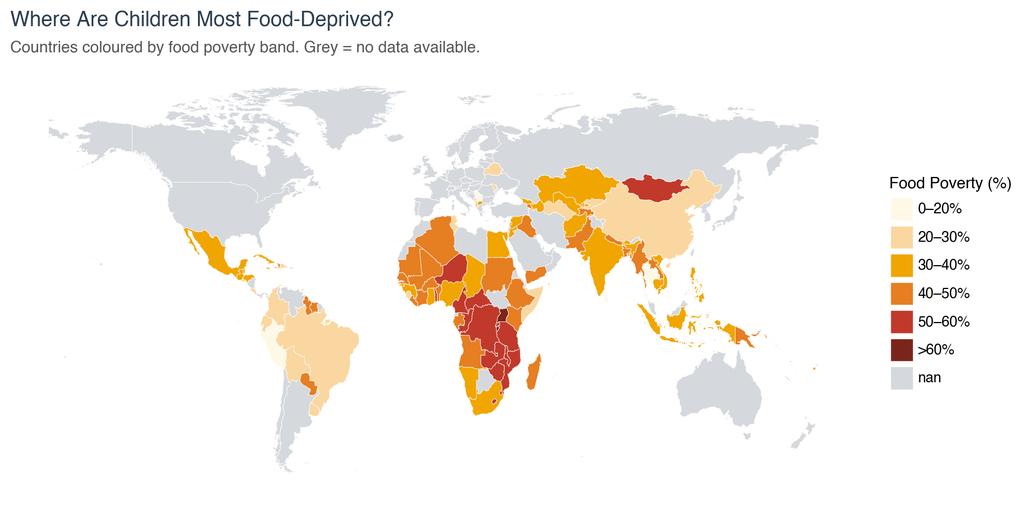

Figure 1: Figure 1: Moderate Food Poverty Rate (%) Among Children 6–23 Months — Most Recent Year per Country. Grey = no data.

```python
# Load the world shapefile — same source used in course lectures
shape_world = gp.read_file(
    "https://public.opendatasoft.com/api/explore/v2.1/catalog/datasets/"
    "world-administrative-boundaries/exports/shp"
)

# Merge food poverty values onto world shape using alpha_3_code
# Left join on iso3 to keep all countries in the shape file
fp_pd = latest_fp.to_pandas()
map_data = (
    shape_world
    .merge(fp_pd[["alpha_3_code", "food_poverty_pct"]],
           left_on="iso3", right_on="alpha_3_code",
           how="left")
)

# Add a discrete food poverty band so the legend shows clear categories
map_data["fp_band"] = pd.cut(
    map_data["food_poverty_pct"],
    bins=[0, 20, 30, 40, 50, 60, 100],
    labels=["0–20%", "20–30%", "30–40%", "40–50%", "50–60%", ">60%"],
)

from plotnine import scale_fill_manual

(
    ggplot(map_data)
    + geom_map(aes(fill="fp_band"), color="white", size=0.15)
    + scale_fill_manual(
        values={
            "0–20%":  "#fef9e7",
            "20–30%": "#fad7a0",
            "30–40%": "#f0a500",
            "40–50%": "#e67e22",
            "50–60%": "#c0392b",
            ">60%":   "#7b241c",
        },
        na_value="#d5d8dc",
        name="Food Poverty (%)",
    )
    + labs(
        title="Where Are Children Most Food-Deprived?",
        subtitle=(
            "Countries coloured by food poverty band. "
            "Grey = no data available."
        ),
        x="", y="",
    )
    + theme_classic()
    + unicef_theme(title_size=13)
    + theme(
        axis_text=element_blank(),
        axis_ticks=element_blank(),
        axis_line=element_blank(),
        panel_grid=element_blank(),
        legend_position="right",
        figure_size=(9, 4.5),
    )
)
```

**Important**

## 4 The Highest-Burden Countries

The world map reveals *where* — the bar chart below reveals *who*. Ranking the 20 countries with the highest recorded food poverty rates shows that almost all are in Sub-Saharan Africa, and several have rates so high that the *majority* of their toddlers are nutritionally deprived.

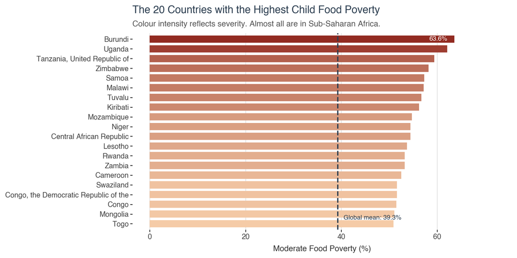

Figure 2: Figure 2: Top 20 Countries by Moderate Food Poverty Rate (%) — Most Recent Year. Dashed line = global mean.

```python
top20 = latest_fp.sort("food_poverty_pct", descending=True).head(20).to_pandas()

(
    ggplot(
        top20,
        aes(x="reorder(country, food_poverty_pct)",
            y="food_poverty_pct",
            fill="food_poverty_pct"),
    )
    + geom_col(show_legend=False, width=0.75)
    + scale_fill_gradient(low="#f5cba7", high="#922b21")
    + coord_flip()
    + geom_hline(
        yintercept=global_mean,
        linetype="dashed", color="#2c3e50", size=0.9
    )
    + annotate(
        "text", x=1.6, y=global_mean + 1.2,
        label=f"Global mean: {global_mean:.1f}%",
        color="#2c3e50", size=8, ha="left"
    )
    + annotate(
        "text", x=20, y=top20.iloc[0]["food_poverty_pct"] - 1.5,
        label=f"{top20.iloc[0]['food_poverty_pct']:.1f}%",
        color="white", size=8, ha="right", fontweight="bold"
    )
    + scale_y_continuous(limits=(0, 72))
    + labs(
        title="The 20 Countries with the Highest Child Food Poverty",
        subtitle="Colour intensity reflects severity. Almost all are in Sub-Saharan Africa.",
        x="", y="Moderate Food Poverty (%)",
    )
    + theme_bw()
    + unicef_theme()
    + theme(panel_grid_major_y=element_blank(), figure_size=(9, 4.5))
)
```

**Important**

**Key finding:** **Burundi** leads at **63.6%** — nearly two in three toddlers there are food-deprived. **Uganda** (62.1%) and **Tanzania, United Republic of** (59.4%) follow closely. All three have experienced prolonged economic hardship, climate stress, or conflict — a pattern of compounding disadvantage.

## 5 Wealth, Life Expectancy & Food Poverty

Does a country’s economic output predict how well it feeds its youngest children? The scatter plot below tests this directly — mapping food poverty against GDP per capita (log scale), coloured by life expectancy group, with a linear regression line revealing the overall trend.

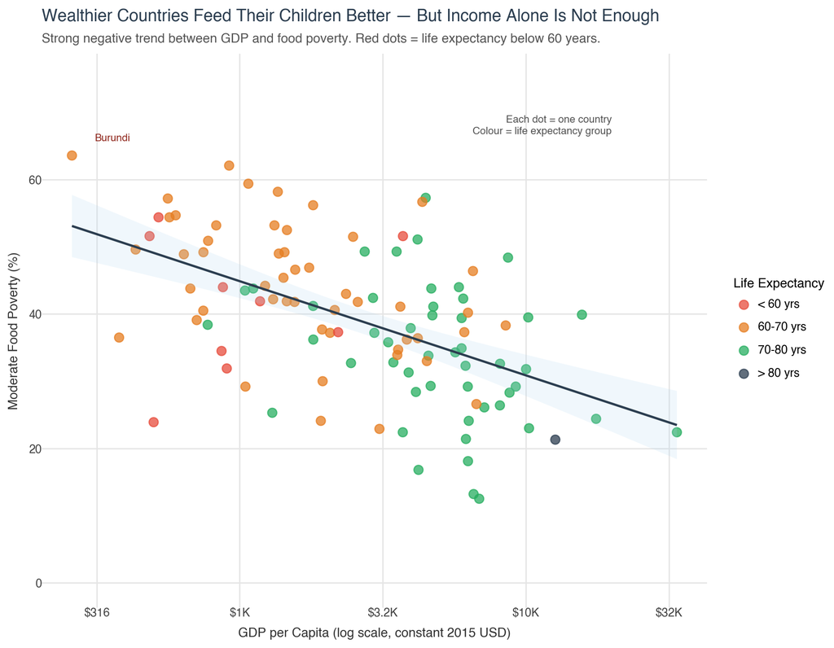

Figure 3: Figure 3: GDP per Capita vs. Moderate Food Poverty Rate — Each dot = one country, coloured by life expectancy group.

```python
merged_pd = merged.to_pandas()

# Log-transform GDP — essential given the vast value range ($200 to $50,000+)
merged_pd["log_gdp"] = np.log10(merged_pd["gdp_per_capita"] + 1)

# Bin life expectancy into four interpretable groups
merged_pd["life_exp_group"] = pd.cut(
    merged_pd["life_expectancy"],
    bins=[0, 60, 70, 80, 100],
    labels=["< 60 yrs", "60-70 yrs", "70-80 yrs", "> 80 yrs"],
)

# Single annotation — Burundi, the highest burden country, sits isolated top-left
burundi = merged_pd[merged_pd["country"] == "Burundi"]

(
    ggplot(merged_pd, aes(x="log_gdp", y="food_poverty_pct", color="life_exp_group"))
    + geom_point(alpha=0.75, size=3.5)
    + geom_smooth(method="lm", color="#2c3e50", fill="#aed6f1", alpha=0.18)
    + geom_text(
        data=burundi,
        mapping=aes(label="country"),
        size=8, color="#922b21", nudge_y=2.5, nudge_x=0.08, ha="left",
    )
    + annotate(
        "text",
        x=4.3, y=68,
        label="Each dot = one country\nColour = life expectancy group",
        size=8, color="#555555", ha="right",
    )
    + scale_color_manual(
        values=["#e74c3c", "#e67e22", "#27ae60", "#2c3e50"],
        name="Life Expectancy",
    )
    + scale_x_continuous(
        breaks=[2.0, 2.5, 3.0, 3.5, 4.0, 4.5],
        labels=["$100", "$316", "$1K", "$3.2K", "$10K", "$32K"],
    )
    + scale_y_continuous(limits=(0, 75))
    + labs(
        title="Wealthier Countries Feed Their Children Better — But Income Alone Is Not Enough",
        subtitle="Strong negative trend between GDP and food poverty. Red dots = life expectancy below 60 years.",
        x="GDP per Capita (log scale, constant 2015 USD)",
        y="Moderate Food Poverty (%)",
    )
    + theme_minimal()
    + unicef_theme()
    + theme(legend_position="right", figure_size=(9, 7))
)
```

**Important**

## 6 Trends Over Time — Is the World Improving?

The final and most critical question: is the world making progress? The time-series below tracks food poverty for ten countries with multiple survey observations. A downward slope means fewer food-deprived children.

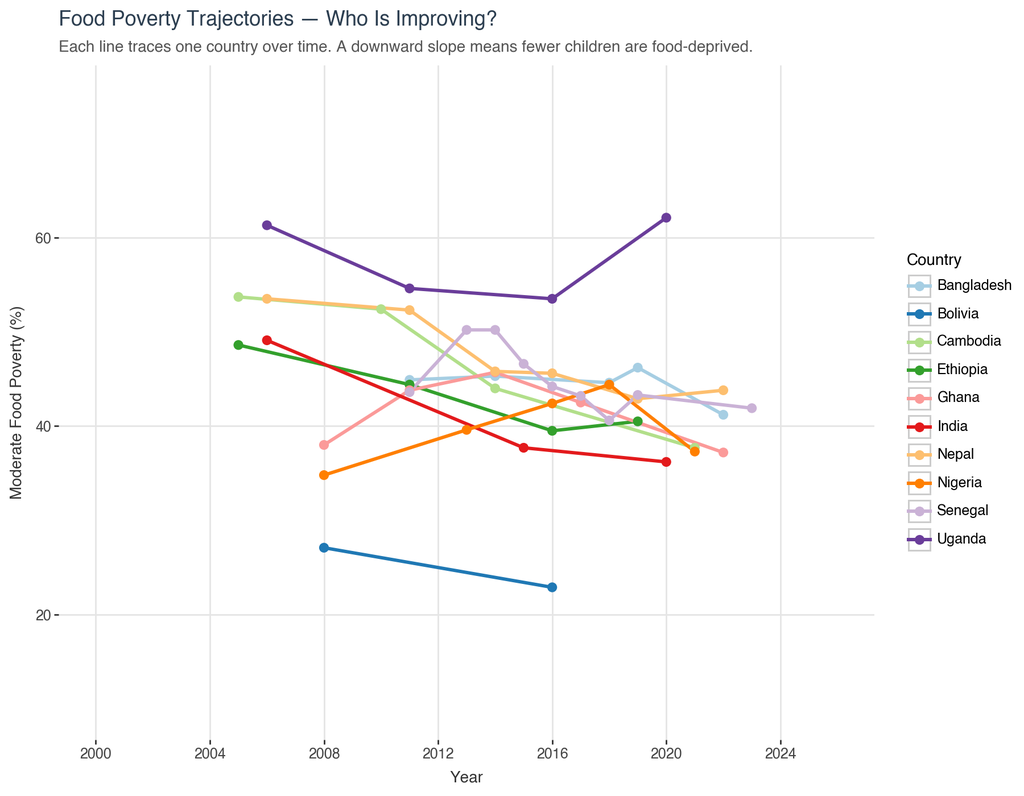

```python
selected_countries = [
    "Bangladesh", "Ethiopia", "India",   "Nigeria",
    "Ghana",      "Cambodia", "Nepal",   "Uganda",
    "Bolivia",    "Senegal",
]

ts_filtered = (
    trend_data
    .filter(pl.col("country").is_in(selected_countries))
    .sort(["country", "year"])
    .to_pandas()
)

(
    ggplot(ts_filtered,
           aes(x="year", y="food_poverty_pct", color="country", group="country"))
    + geom_line(size=1.2)
    + geom_point(size=2.5)
    + scale_color_brewer(type="qual", palette="Paired", name="Country")
    + scale_x_continuous(breaks=list(range(2000, 2028, 4)), limits=(2000, 2026))
    + scale_y_continuous(limits=(10, 75))
    + labs(
        title="Food Poverty Trajectories — Who Is Improving?",
        subtitle="Each line traces one country over time. A downward slope means fewer children are food-deprived.",
        x="Year", y="Moderate Food Poverty (%)",
    )
    + theme_bw()
    + unicef_theme()
    + theme(
        legend_position="right",
        figure_size=(9, 7),
    )
)
```

**Country-level change statistics**

```python
# Compute per-country change from first to most recent survey
changes = (
    ts_filtered.groupby("country")
    .agg(
        start=("food_poverty_pct", "first"),
        end=("food_poverty_pct",   "last"),
        start_year=("year",        "min"),
        end_year=("year",          "max"),
    )
    .reset_index()
    .assign(change=lambda d: (d["end"] - d["start"]).round(1))
    .sort_values("change")
    .rename(columns={
        "country":    "Country",
        "start_year": "First Survey",
        "end_year":   "Latest Survey",
        "start":      "Rate at Start (%)",
        "end":        "Rate at End (%)",
        "change":     "Change (pp)",
    })
)

print("Country-level change in moderate food poverty (percentage points):")
print(changes.to_string(index=False))
```

```
Country-level change in moderate food poverty (percentage points):
   Country  Rate at Start (%)  Rate at End (%)  First Survey  Latest Survey  Change (pp)
  Cambodia               53.7             37.7          2005           2021        -16.0
     India               49.1             36.2          2006           2020        -12.9
     Nepal               53.5             43.8          2006           2022         -9.7
  Ethiopia               48.6             40.5          2005           2019         -8.1
   Bolivia               27.1             22.9          2008           2016         -4.2
Bangladesh               44.9             41.2          2011           2022         -3.7
   Senegal               43.6             41.9          2011           2023         -1.7
     Ghana               38.0             37.2          2008           2022         -0.8
    Uganda               61.3             62.1          2006           2020          0.8
   Nigeria               34.8             37.3          2008           2021          2.5
```

**Tip**

**Key finding:** **Cambodia** achieved the largest reduction — a **16 percentage point** drop between 2005 and 2021 — driven by sustained economic growth and deliberate nutrition policy. **India** reduced its rate by nearly 13 points. By contrast, **Uganda** and **Nigeria** show negligible progress, demonstrating how structural barriers — conflict, rapid population growth, governance gaps — can neutralise even well-funded interventions.

## 7 Conclusion

**Note**

The four visualisations in this report converge on a single, uncomfortable truth: **moderate food poverty among young children remains one of the world’s most persistent and inequitable crises.**

**Geography matters enormously.** Sub-Saharan Africa carries a disproportionate share of the global burden, with rates above 60% in the worst-affected countries. The world map makes this pattern impossible to ignore.

**Wealth helps, but is not sufficient.** The strong negative relationship between GDP per capita and food poverty is clear. Yet middle-income outliers demonstrate that income growth alone does not guarantee nutritional progress — policy design and governance matter independently.

**The gap is not inevitable.** The distance between the best and worst performers is not fixed by geography or fate — it is the product of political choices, funding decisions, and governance quality. That means it can be changed.

> *The youngest children cannot advocate for themselves. That responsibility belongs to all of us.*

*Data: UNICEF Global Indicators Database · World Bank Macroeconomic Indicators.*  
*Analysis: Python 3.9 · Polars · GeoPandas · Plotnine · Quarto.*